# StateMigrationVisualization

## First step: we import data and play with it a bit

We want to solve the following questions:

[figure not shown]

```python
# Import and exel file using pandas
import pandas as pd
# Read Excel file
df = pd.read_excel('MigrationData.xlsx')
# print(df)

df1 = df
df1 = df1.rename({'Migrant Persons' : 'Migrant Persons X 1e6'}, axis=1)
df1 = df1.rename({'Migrant Males' : 'Migrant Males %'}, axis=1)
df1['Migrant Males %'] = df1['Migrant Males %']/df1['Migrant Persons X 1e6']*100
print(df1.head()) # to test that all is properly imported
```

```
             Home State Name  Home State ID    Current State  \
0                DAMAN & DIU             25  JAMMU & KASHMIR
1       DADRA & NAGAR HAVELI             26  JAMMU & KASHMIR
2                 PUDUCHERRY             34  JAMMU & KASHMIR
3  ANDAMAN & NICOBAR ISLANDS             35  JAMMU & KASHMIR
4                    MIZORAM             15  JAMMU & KASHMIR

   Current State ID  Migrant Persons X 1e6  Migrant Males %  Migrant Females
0                 1                      6        50.000000                3
1                 1                     17        23.529412               13
2                 1                     18        33.333333               12
3                 1                     51        49.019608               26
4                 1                     57        38.596491               35
```

```python
print(df['Current State'].unique())
print(df['Current State ID'].unique())
```

```
['JAMMU & KASHMIR' 'HIMACHAL PRADESH' 'PUNJAB' 'CHANDIGARH' 'UTTARAKHAND'
 'HARYANA' 'NCT OF DELHI' 'RAJASTHAN' 'UTTAR PRADESH' 'BIHAR' 'SIKKIM'
 'ARUNACHAL PRADESH' 'NAGALAND' 'MANIPUR' 'MIZORAM' 'TRIPURA' 'MEGHALAYA'
 'ASSAM' 'WEST BENGAL' 'JHARKHAND' 'ODISHA' 'CHHATTISGARH'
 'MADHYA PRADESH' 'GUJARAT' 'DAMAN & DIU' 'DADRA & NAGAR HAVELI'
 'MAHARASHTRA' 'ANDHRA PRADESH' 'KARNATAKA' 'GOA' 'LAKSHADWEEP' 'KERALA'
 'TAMIL NADU' 'PUDUCHERRY' 'ANDAMAN & NICOBAR ISLANDS']
[ 1  2  3  4  5  6  7  8  9 10 11 12 13 14 15 16 17 18 19 20 21 22 23 24
 25 26 27 28 29 30 31 32 33 34 35]
```

Let us make an ID file. We will use this dataframe throughout the notebook.

```python
# initialize list elements
data = {'ID': df['Current State ID'].unique(),
        'State': df['Current State'].unique()}

IDs = pd.DataFrame(data)

# print dataframe.
print(IDs)
```

```
    ID                      State
0    1            JAMMU & KASHMIR
1    2           HIMACHAL PRADESH
2    3                     PUNJAB
3    4                 CHANDIGARH
4    5                UTTARAKHAND
5    6                    HARYANA
6    7               NCT OF DELHI
7    8                  RAJASTHAN
8    9              UTTAR PRADESH
9   10                      BIHAR
10  11                     SIKKIM
11  12          ARUNACHAL PRADESH
12  13                   NAGALAND
13  14                    MANIPUR
```

[output cut: 21 more lines]

### Plotting the global data

Here, we will plot how many workers migrated from a given state and to which state.

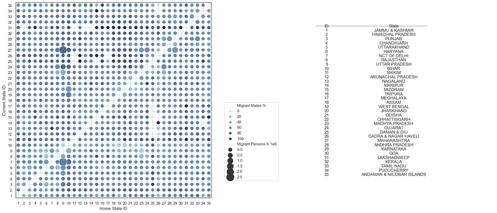

```python
import seaborn as sns
import matplotlib.pyplot as plt
import numpy as np
import matplotlib.ticker as ticker

sns.set_theme(style="whitegrid")

# Load the example planets dataset
# planets = sns.load_dataset("planets")
fig, (ax1, ax2) = plt.subplots(1, 2)
fig.set_size_inches(25, 10)

xmin, xmax = min(IDs['ID'])-0.5, max(IDs['ID'])+0.5
ax1.plot([xmin, xmax], [xmin, xmin],'k-', lw=3)
ax1.plot([xmax, xmax], [xmin, xmax],'k-', lw=3)
ax1.plot([xmin, xmax], [xmax, xmax],'k-', lw=3)
ax1.plot([xmin, xmin], [xmin, xmax],'k-', lw=3)

cmap = sns.cubehelix_palette(rot=-.2, as_cmap=True)

g = sns.scatterplot(
    data=df1,
    x="Home State ID", y="Current State ID",
    size="Migrant Persons X 1e6", hue="Migrant Males %",
    palette=cmap, sizes=(100, 500), ax=ax1
)

ax1.xaxis.grid(True, "minor", linewidth=.25)
ax1.yaxis.grid(True, "minor", linewidth=.25)
ax1.set_aspect('equal')
ax1.set_xlim(0.5, 35.5)
ax1.set_ylim(0.5, 35.5)
ax1.legend(bbox_to_anchor=(0.85, 0, 0.5, 0.5))

start, end = ax1.get_xlim()
ax1.xaxis.set_ticks(np.arange(start+0.5, end-0.5+1, 1))
ax1.xaxis.set_major_formatter(ticker.FormatStrFormatter('%d'))
ax1.yaxis.set_ticks(np.arange(start+0.5, end-0.5+1, 1))
ax1.yaxis.set_major_formatter(ticker.FormatStrFormatter('%d'))

ax2.axis('off')
ax2.table(cellText=IDs.values, colLabels=IDs.columns, loc='center', colWidths=[0.1, 0.5],cellLoc='center',edges='open')

import matplotlib.lines as lines
yL = 0.88
line = lines.Line2D([0.2, 0.7], [yL, yL],
                    lw=0.5, color='black', axes=ax2)
ax2.add_line(line)
```

### Shortcoming of this plot:

We do not really see any details becuase of the large numbers included in this case. In the subsequent questions, we will make use of specific questions to understand the data better.

## Question 1

Now we do question 1. To keep things simple, we will use brute force.

To start, let us first calculate the total number of workers migrating out from a particular state

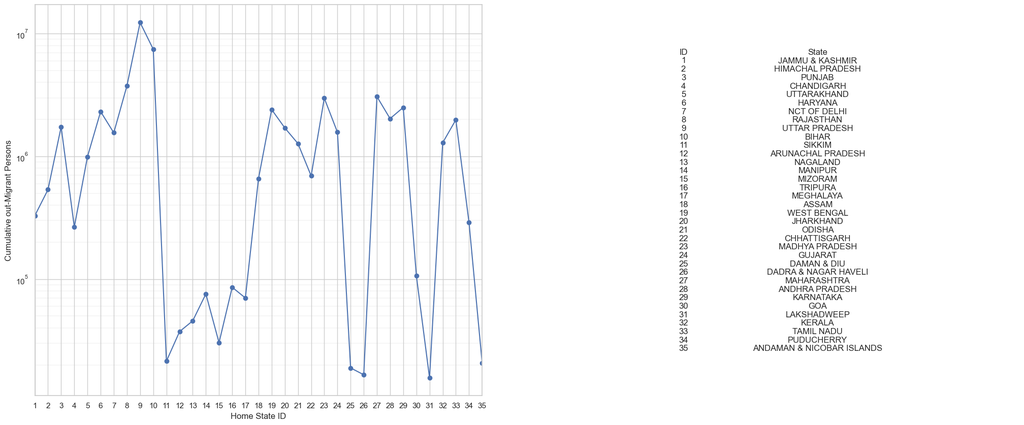

```python
# Now, we get a sum of migrants from a particular Home State
df2em = df.groupby(['Home State ID']).sum()

# Plot Migrant Persons against Home State ID
# print(df2em.index)
fig, (ax, ax0) = plt.subplots(1,2)
fig.set_size_inches(25, 10)
ax.plot(df2em.index, df2em['Migrant Persons'], 'o-')
ax.xaxis.grid(True, "minor", linewidth=.25)
ax.yaxis.grid(True, "minor", linewidth=.25)
ax.set_xlim(1, 35)
start, end = ax1.get_xlim()
ax.xaxis.set_ticks(np.arange(1, 36, 1))
ax.xaxis.set_major_formatter(ticker.FormatStrFormatter('%d'))
ax.set_xlabel('Home State ID')
ax.set_ylabel('Cumulative out-Migrant Persons')

# set yaxis to log scale
ax.set_yscale('log')

ax0.axis('off')
ax0.table(cellText=IDs.values, colLabels=IDs.columns, loc='center', colWidths=[0.1, 0.5],cellLoc='center',edges='open')
```

- Clearly, we see that by far the most workers are migrating out of Uttar Pradesh. This is followed by Bihar and Rajasthan. This is inline with our previous plot.

For better visualization, we will plot the above line graph onto the map of India. This way, we can keep track of the states and their migration patterns.

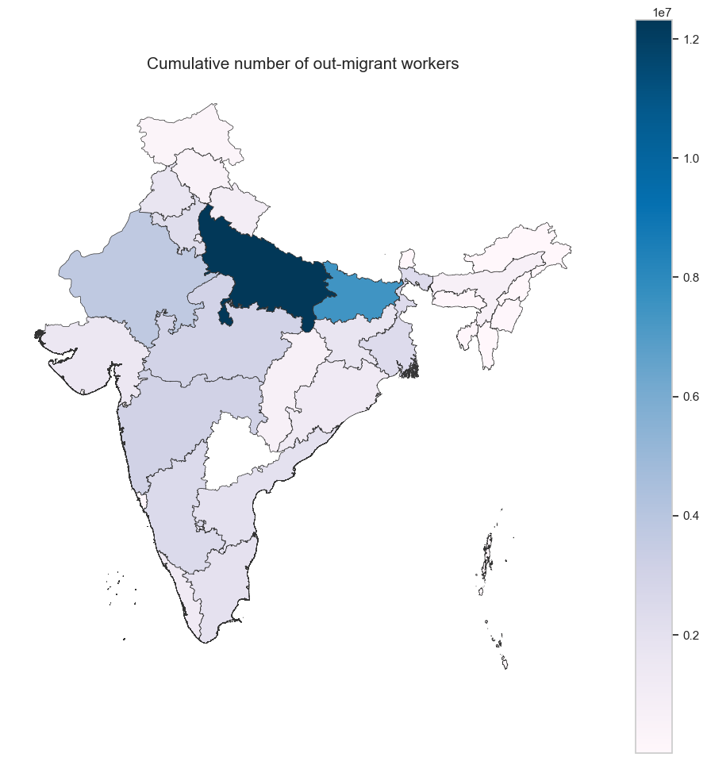

```python
import geopandas as gpd

df6id = df2em.index.to_numpy()
df6value = df2em['Migrant Persons'].to_numpy()

data = {'ID': df6id,
        'Migrant persons': df6value}

df6em = pd.DataFrame(data)

df7em = pd.merge(IDs, df6em, on="ID", how="left")
# print(df7)

map_dfem = gpd.read_file('IND_adm/IND_adm1.shp')
# Rename some states
map_dfem = map_dfem.replace({'Andaman and Nicobar':'ANDAMAN & NICOBAR ISLANDS', 'Andhra Pradesh':'ANDHRA PRADESH', 'Arunachal Pradesh':'ARUNACHAL PRADESH', 'Chhattisgarh':'CHHATTISGARH', 'Dadra and Nagar Haveli':'DADRA & NAGAR HAVELI', 'Daman and Diu':'DAMAN & DIU', 'Delhi':'NCT OF DELHI', 'Jammu and Kashmir':'JAMMU & KASHMIR', 'Lakshadweep':'LAKSHADWEEP', 'Madhya Pradesh':'MADHYA PRADESH', 'Maharashtra':'MAHARASHTRA', 'Bihar':'BIHAR', 'Assam':'ASSAM', 'Chandigarh':'CHANDIGARH','Goa':'GOA','Gujarat':'GUJARAT','Haryana':'HARYANA','Himachal Pradesh':'HIMACHAL PRADESH','Jharkhand':'JHARKHAND','Karnataka':'KARNATAKA','Kerala':'KERALA','Mizoram':'MIZORAM','Nagaland':'NAGALAND','Orissa':'ODISHA','Puducherry':'PUDUCHERRY','Punjab':'PUNJAB','Rajasthan':'RAJASTHAN','Sikkim':'SIKKIM','Tamil Nadu':'TAMIL NADU','Telangana':'TELANGANA','Tripura':'TRIPURA','Uttar Pradesh':'UTTAR PRADESH','Uttarakhand':'UTTARAKHAND','West Bengal':'WEST BENGAL','Uttaranchal':'UTTARAKHAND','Manipur':'MANIPUR','Meghalaya':'MEGHALAYA'})
# print(map_df)
dfMergeem = pd.merge(map_dfem, df7em, left_on='NAME_1', right_on='State', how='left')
# print(dfMerge)
fig, ax = plt.subplots(1, figsize=(12, 12))
ax.axis('off')
ax.set_title('Cumulative number of out-migrant workers',
             fontdict={'fontsize': '15', 'fontweight' : '3'})
fig = dfMergeem.plot(column='Migrant persons', cmap='PuBu', linewidth=0.5, ax=ax, edgecolor='0.2',legend=True)
```

Dark blue states are those with the highest number of workers migrating out. Light blue states are those with the lowest number of workers migrating out.

- Clearly, once again UP stands out.
- Unfortunately, there was no Telengana in the datafile. So, we have skipped it.

### Finding the neighbours of a given state

Here, we will use geopanda to find the neighbours of a given state. We will use this to find the states that are most likely to be migrated to from a given state.

```python
from sre_parse import State


map_dfem2 = gpd.read_file('IND_adm/IND_adm1.shp')
# Rename some states
map_dfem2 = map_dfem2.replace({'Andaman and Nicobar':'ANDAMAN & NICOBAR ISLANDS', 'Andhra Pradesh':'ANDHRA PRADESH', 'Arunachal Pradesh':'ARUNACHAL PRADESH', 'Chhattisgarh':'CHHATTISGARH', 'Dadra and Nagar Haveli':'DADRA & NAGAR HAVELI', 'Daman and Diu':'DAMAN & DIU', 'Delhi':'NCT OF DELHI', 'Jammu and Kashmir':'JAMMU & KASHMIR', 'Lakshadweep':'LAKSHADWEEP', 'Madhya Pradesh':'MADHYA PRADESH', 'Maharashtra':'MAHARASHTRA', 'Bihar':'BIHAR', 'Assam':'ASSAM', 'Chandigarh':'CHANDIGARH','Goa':'GOA','Gujarat':'GUJARAT','Haryana':'HARYANA','Himachal Pradesh':'HIMACHAL PRADESH','Jharkhand':'JHARKHAND','Karnataka':'KARNATAKA','Kerala':'KERALA','Mizoram':'MIZORAM','Nagaland':'NAGALAND','Orissa':'ODISHA','Puducherry':'PUDUCHERRY','Punjab':'PUNJAB','Rajasthan':'RAJASTHAN','Sikkim':'SIKKIM','Tamil Nadu':'TAMIL NADU','Telangana':'TELANGANA','Tripura':'TRIPURA','Uttar Pradesh':'UTTAR PRADESH','Uttarakhand':'UTTARAKHAND','West Bengal':'WEST BENGAL','Uttaranchal':'UTTARAKHAND','Manipur':'MANIPUR','Meghalaya':'MEGHALAYA'})

# map_dfem2.plot()
# add NEIGHBORS column
map_dfem2["NEIGHBORS"] = None

for index, State in map_dfem2.iterrows():

    # get 'not disjoint' countries
    neighbors = map_dfem2[~map_dfem2.geometry.disjoint(State.geometry)].NAME_1.tolist()

    # remove own name of the country from the list
    neighbors = [ name for name in neighbors if State.NAME_1 != name ]

    # add names of neighbors as NEIGHBORS value
    map_dfem2.at[index, "NEIGHBORS"] = ", ".join(neighbors)

# print(map_dfem2)

map_dfem3StatesTemp = map_dfem2['NAME_1'].to_numpy()
map_dfem3NeighboursTemp = map_dfem2['NEIGHBORS'].to_numpy()

data = {'Home State Name': map_dfem3StatesTemp,
        'Neighbouring states': map_dfem3NeighboursTemp}

map_dfem3 = pd.DataFrame(data)

# print(map_dfem3)
```

df is our base dataframe. map_dfem3 is the dataframe that has all the states and their corresponding neighbours.

```python
print(map_dfem3.head())
```

```
             Home State Name  \
0  ANDAMAN & NICOBAR ISLANDS
1             ANDHRA PRADESH
2          ARUNACHAL PRADESH
3                      ASSAM
4                      BIHAR

                                 Neighbouring states
0
1  KARNATAKA, ODISHA, PUDUCHERRY, TAMIL NADU, TEL...
2                                    ASSAM, NAGALAND
3  ARUNACHAL PRADESH, MANIPUR, MEGHALAYA, MIZORAM...
4              JHARKHAND, UTTAR PRADESH, WEST BENGAL
```

```python
print(df.head())
```

```
             Home State Name  Home State ID    Current State  \
0                DAMAN & DIU             25  JAMMU & KASHMIR
1       DADRA & NAGAR HAVELI             26  JAMMU & KASHMIR
2                 PUDUCHERRY             34  JAMMU & KASHMIR
3  ANDAMAN & NICOBAR ISLANDS             35  JAMMU & KASHMIR
4                    MIZORAM             15  JAMMU & KASHMIR

   Current State ID  Migrant Persons  Migrant Males  Migrant Females
0                 1                6              3                3
1                 1               17              4               13
2                 1               18              6               12
3                 1               51             25               26
4                 1               57             22               35
```

### The most important part of the code to calculate the number of migrations to the neighbouring states

Here, we loop over all the states to find the percentage of workers migrating to the neighbouring states.

```python
# sort based on Home State Name
df9em = df.sort_values(by=['Home State Name'])
# print(df9em)

neighborPercent = []
counter = 0
for state in map_dfem3['Home State Name']:
    # print("Doing %s" % state)
    df10em = df9em[df9em['Home State Name'] == state]
    TotalMigrants = df10em['Migrant Persons'].sum()
    # print(df10em)

    neighbors = map_dfem3['Neighbouring states'][counter]
    neighbors = neighbors.split(", ")
    # print(df10em)
    NeighborMigrant = 0
    for neighbor in neighbors:
      df11em = df10em[df10em['Current State'] == neighbor]
      NeighborMigrant += df11em['Migrant Persons'].sum()
        # df9em = df9em[df9em['Home State Name'] != neighbor]
    # % of migrants going to neighboring states
    if TotalMigrants != 0:
      NeighborMigrant = (NeighborMigrant/TotalMigrants)*100
    else:
      NeighborMigrant = 0
    print("Percentage Migrants from %s to neighbours is %d percent" % (state, NeighborMigrant))
    neighborPercent.append(NeighborMigrant)

    # if counter == 1:
    #   break
    counter = counter + 1
```

```
Percentage Migrants from ANDAMAN & NICOBAR ISLANDS to neighbours is 0 percent
Percentage Migrants from ANDHRA PRADESH to neighbours is 65 percent
Percentage Migrants from ARUNACHAL PRADESH to neighbours is 54 percent
Percentage Migrants from ASSAM to neighbours is 63 percent
Percentage Migrants from BIHAR to neighbours is 47 percent
Percentage Migrants from CHANDIGARH to neighbours is 83 percent
Percentage Migrants from CHHATTISGARH to neighbours is 81 percent
Percentage Migrants from DADRA & NAGAR HAVELI to neighbours is 83 percent
Percentage Migrants from DAMAN & DIU to neighbours is 76 percent
Percentage Migrants from NCT OF DELHI to neighbours is 66 percent
Percentage Migrants from GOA to neighbours is 85 percent
Percentage Migrants from GUJARAT to neighbours is 84 percent
Percentage Migrants from HARYANA to neighbours is 90 percent
Percentage Migrants from HIMACHAL PRADESH to neighbours is 61 percent
Percentage Migrants from JAMMU & KASHMIR to neighbours is 26 percent
Percentage Migrants from JHARKHAND to neighbours is 75 percent
Percentage Migrants from KARNATAKA to neighbours is 95 percent
Percentage Migrants from KERALA to neighbours is 62 percent
Percentage Migrants from LAKSHADWEEP to neighbours is 0 percent
Percentage Migrants from MADHYA PRADESH to neighbours is 87 percent
Percentage Migrants from MAHARASHTRA to neighbours is 73 percent
Percentage Migrants from MANIPUR to neighbours is 50 percent
Percentage Migrants from MEGHALAYA to neighbours is 57 percent
Percentage Migrants from MIZORAM to neighbours is 74 percent
Percentage Migrants from NAGALAND to neighbours is 57 percent
Percentage Migrants from ODISHA to neighbours is 54 percent
Percentage Migrants from PUDUCHERRY to neighbours is 97 percent
Percentage Migrants from PUNJAB to neighbours is 61 percent
Percentage Migrants from RAJASTHAN to neighbours is 62 percent
Percentage Migrants from SIKKIM to neighbours is 53 percent
Percentage Migrants from TAMIL NADU to neighbours is 79 percent
Percentage Migrants from TELANGANA to neighbours is 0 percent
Percentage Migrants from TRIPURA to neighbours is 53 percent
Percentage Migrants from UTTAR PRADESH to neighbours is 58 percent
Percentage Migrants from UTTARAKHAND to neighbours is 41 percent
Percentage Migrants from WEST BENGAL to neighbours is 42 percent
```

neighborPercent variable stores the percentage of workers migrating to the neighbouring states.

```python
print(neighborPercent)
```

```
[0.0, 65.61292490064059, 54.5546992078784, 63.66300133092009, 47.12418613692903, 83.37480472058574, 81.38551854585717, 83.22813345356177, 76.70051835396171, 66.4719322910375, 85.26498173189198, 84.38215314067011, 90.91028815824414, 61.32043603951305, 26.104907287204448, 75.20950806152179, 95.2290811…
```

Let us make neighborPercent into a panda dataframe

```python
data = {'Home State Name': map_dfem3['Home State Name'],
        'Neighbor Percent migration': neighborPercent}

df12em = pd.DataFrame(data)
print(df12em.head())
```

```
             Home State Name  Neighbor Percent migration
0  ANDAMAN & NICOBAR ISLANDS                    0.000000
1             ANDHRA PRADESH                   65.612925
2          ARUNACHAL PRADESH                   54.554699
3                      ASSAM                   63.663001
4                      BIHAR                   47.124186
```

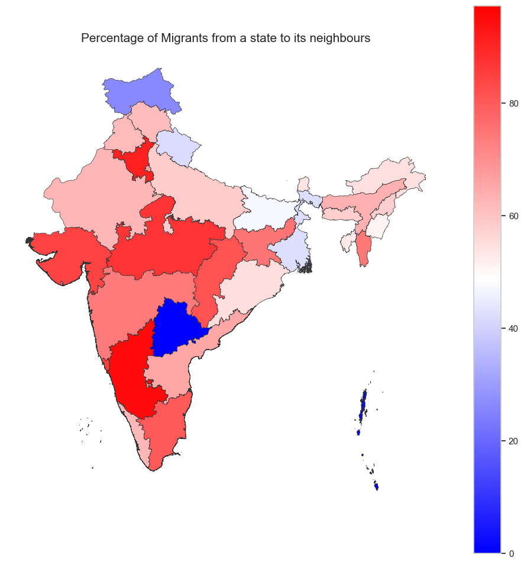

```python
map_dfNeighbour = gpd.read_file('IND_adm/IND_adm1.shp')
# Rename some states
map_dfNeighbour = map_dfNeighbour.replace({'Andaman and Nicobar':'ANDAMAN & NICOBAR ISLANDS', 'Andhra Pradesh':'ANDHRA PRADESH', 'Arunachal Pradesh':'ARUNACHAL PRADESH', 'Chhattisgarh':'CHHATTISGARH', 'Dadra and Nagar Haveli':'DADRA & NAGAR HAVELI', 'Daman and Diu':'DAMAN & DIU', 'Delhi':'NCT OF DELHI', 'Jammu and Kashmir':'JAMMU & KASHMIR', 'Lakshadweep':'LAKSHADWEEP', 'Madhya Pradesh':'MADHYA PRADESH', 'Maharashtra':'MAHARASHTRA', 'Bihar':'BIHAR', 'Assam':'ASSAM', 'Chandigarh':'CHANDIGARH','Goa':'GOA','Gujarat':'GUJARAT','Haryana':'HARYANA','Himachal Pradesh':'HIMACHAL PRADESH','Jharkhand':'JHARKHAND','Karnataka':'KARNATAKA','Kerala':'KERALA','Mizoram':'MIZORAM','Nagaland':'NAGALAND','Orissa':'ODISHA','Puducherry':'PUDUCHERRY','Punjab':'PUNJAB','Rajasthan':'RAJASTHAN','Sikkim':'SIKKIM','Tamil Nadu':'TAMIL NADU','Telangana':'TELANGANA','Tripura':'TRIPURA','Uttar Pradesh':'UTTAR PRADESH','Uttarakhand':'UTTARAKHAND','West Bengal':'WEST BENGAL','Uttaranchal':'UTTARAKHAND','Manipur':'MANIPUR','Meghalaya':'MEGHALAYA'})
# print(map_df)
dfMergeem = pd.merge(map_dfNeighbour, df12em, left_on='NAME_1', right_on='Home State Name', how='left')
# print(dfMerge)
fig, ax = plt.subplots(1, figsize=(12, 12))
ax.axis('off')
ax.set_title('Percentage of Migrants from a state to its neighbours',
             fontdict={'fontsize': '15', 'fontweight' : '3'})
fig = dfMergeem.plot(column='Neighbor Percent migration', cmap='bwr', linewidth=0.5, ax=ax, edgecolor='0.2',legend=True)
```

Red denotes the states with highest number of workers migrating to the neighbouring states. Blue denotes the states with the lowest number of workers migrating to the neighbouring states.

In the above map of India, we have plotted the percentage of workers migrating to the neighbouring states. Clearly, the southern states have the highest percentage of workers migrating to the neighbouring states.

To further understnad the data, we can make bar plots of the states with the highest number of workers migrating to the neighbouring states.

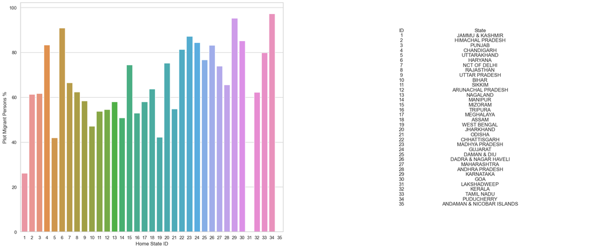

```python
sns.set_theme(style="whitegrid")

df13em = pd.merge(IDs, df12em, left_on='State', right_on='Home State Name', how='left')
# print(df13em)
# Plot Migrant Persons % to neighbour against Home State ID
fig, (ax10, ax12) = plt.subplots(1,2)
fig.set_size_inches(25, 10)
sns.barplot(x="ID", y="Neighbor Percent migration", data=df13em,ax=ax10)
ax10.xaxis.grid(True, "minor", linewidth=.25)
ax10.yaxis.grid(True, "minor", linewidth=.25)
ax10.set_xlabel('Home State ID')
ax10.set_ylabel('Plot Migrant Persons %')

ax12.axis('off')
ax12.table(cellText=IDs.values, colLabels=IDs.columns, loc='center', colWidths=[0.1, 0.5],cellLoc='center',edges='open')
```

## End of Question 1

## Question (2)

In this question, we need to find the top 10 employing states.

Idea is to first group and sum the data based on this group. Then plot it using a line plot to visualize the data.

After that, we can sort this group based on highest number of migrant persons.

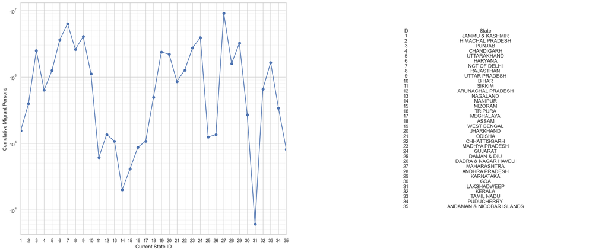

```python
# Now, we get a sum of migrants to a particular Current State

df2 = df.groupby(['Current State ID']).sum()

# Plot Migrant Persons against Current State ID
# print(df2.index)
fig, (ax, ax0) = plt.subplots(1,2)
fig.set_size_inches(25, 10)
ax.plot(df2.index, df2['Migrant Persons'], 'o-')
ax.xaxis.grid(True, "minor", linewidth=.25)
ax.yaxis.grid(True, "minor", linewidth=.25)
ax.set_xlim(1, 35)
start, end = ax1.get_xlim()
ax.xaxis.set_ticks(np.arange(1, 36, 1))
ax.xaxis.set_major_formatter(ticker.FormatStrFormatter('%d'))
ax.set_xlabel('Current State ID')
ax.set_ylabel('Cumulative Migrant Persons')

# set yaxis to log scale
ax.set_yscale('log')

ax0.axis('off')
ax0.table(cellText=IDs.values, colLabels=IDs.columns, loc='center', colWidths=[0.1, 0.5],cellLoc='center',edges='open')
```

As we saw in the previous plots, Maharashtra and Delhi are the top 2 states with the highest number of migrant workers.

Surprisingly, UP is third in this list. This implies that UP does not only have the highest emigration but also has one of the highest immigration.

To further enhance the interpretation of this data, let us plot on the map of India

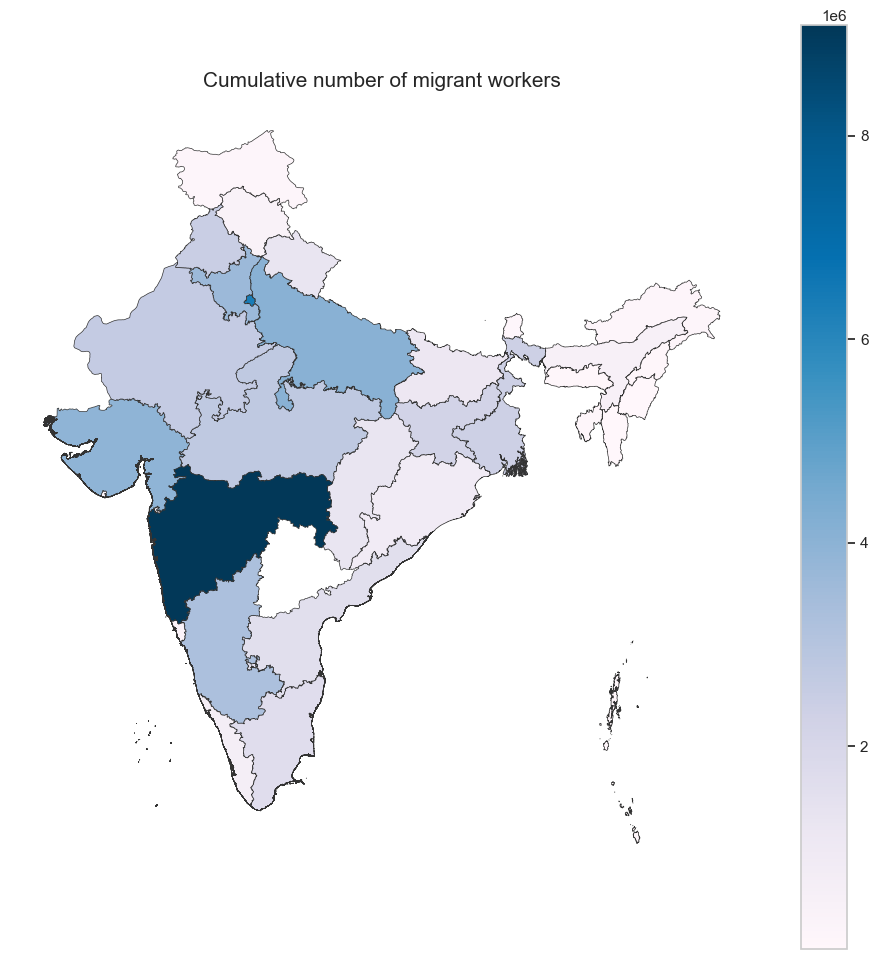

```python
df6id = df2.index.to_numpy()
df6value = df2['Migrant Persons'].to_numpy()

data = {'ID': df6id,
        'Migrant persons': df6value}

df6 = pd.DataFrame(data)

df7 = pd.merge(IDs, df6, on="ID", how="left")
# print(df7)

import geopandas as gpd
# Read shapefile using Geopandas
map_df = gpd.read_file('IND_adm/IND_adm1.shp')
# Rename some states
map_df = map_df.replace({'Andaman and Nicobar':'ANDAMAN & NICOBAR ISLANDS', 'Andhra Pradesh':'ANDHRA PRADESH', 'Arunachal Pradesh':'ARUNACHAL PRADESH', 'Chhattisgarh':'CHHATTISGARH', 'Dadra and Nagar Haveli':'DADRA & NAGAR HAVELI', 'Daman and Diu':'DAMAN & DIU', 'Delhi':'NCT OF DELHI', 'Jammu and Kashmir':'JAMMU & KASHMIR', 'Lakshadweep':'LAKSHADWEEP', 'Madhya Pradesh':'MADHYA PRADESH', 'Maharashtra':'MAHARASHTRA', 'Bihar':'BIHAR', 'Assam':'ASSAM', 'Chandigarh':'CHANDIGARH','Goa':'GOA','Gujarat':'GUJARAT','Haryana':'HARYANA','Himachal Pradesh':'HIMACHAL PRADESH','Jharkhand':'JHARKHAND','Karnataka':'KARNATAKA','Kerala':'KERALA','Mizoram':'MIZORAM','Nagaland':'NAGALAND','Orissa':'ODISHA','Puducherry':'PUDUCHERRY','Punjab':'PUNJAB','Rajasthan':'RAJASTHAN','Sikkim':'SIKKIM','Tamil Nadu':'TAMIL NADU','Telangana':'TELANGANA','Tripura':'TRIPURA','Uttar Pradesh':'UTTAR PRADESH','Uttarakhand':'UTTARAKHAND','West Bengal':'WEST BENGAL','Uttaranchal':'UTTARAKHAND','Manipur':'MANIPUR','Meghalaya':'MEGHALAYA'})
# print(map_df)
dfMerge = pd.merge(map_df, df7, left_on='NAME_1', right_on='State', how='left')
# print(dfMerge)
fig, ax = plt.subplots(1, figsize=(12, 12))
ax.axis('off')
ax.set_title('Cumulative number of migrant workers',
             fontdict={'fontsize': '15', 'fontweight' : '3'})
fig = dfMerge.plot(column='Migrant persons', cmap='PuBu', linewidth=0.5, ax=ax, edgecolor='0.2',legend=True)
```

There is no Telengana in the data. So, I have removed it from the plot.

```python
# sort the data frame by Migrant Persons

df3 = df2.sort_values(by=['Migrant Persons'], ascending=False)
# top 10 states with highest number of migrants
df4 = df3.head(10)
# print(df4)

df5id = df4.index.to_numpy()
df5value = df4['Migrant Persons'].to_numpy()

data = {'ID': df5id,
        'Migrant persons': df5value}

df5 = pd.DataFrame(data)

print(df5)
```

```
   ID  Migrant persons
0  27          9087380
1   7          6330065
2   9          4061933
3  24          3916075
4   6          3626318
5  29          3247660
6  23          2744332
7   8          2604298
8   3          2488299
9  19          2381045
```

So, we have the id of the top ten employing states. Now, we need to find their names. For this, we will use the IDs dataframe that we created earlier.

```python
# find index of top 10 states from IDs
IDs3 = IDs[IDs['ID'].isin(df4.index)]
# print(IDs3)

Tempid = IDs3['ID'].to_numpy()
Tempvalue = IDs3['State'].to_numpy()
Tempdata = {'ID': Tempid,
        'State': Tempvalue}

IDs4 = pd.DataFrame(Tempdata)
print(IDs4)
```

```
   ID           State
0   3          PUNJAB
1   6         HARYANA
2   7    NCT OF DELHI
3   8       RAJASTHAN
4   9   UTTAR PRADESH
5  19     WEST BENGAL
6  23  MADHYA PRADESH
7  24         GUJARAT
8  27     MAHARASHTRA
9  29       KARNATAKA
```

Of course, we need to arrange these states based on the migrant population as available in df5

```python
IDs4 = IDs4.set_index('ID')
IDs4 = IDs4.reindex(index=df5['ID'])
IDs4 = IDs4.reset_index()
print(IDs4)
```

```
   ID           State
0  27     MAHARASHTRA
1   7    NCT OF DELHI
2   9   UTTAR PRADESH
3  24         GUJARAT
4   6         HARYANA
5  29       KARNATAKA
6  23  MADHYA PRADESH
7   8       RAJASTHAN
8   3          PUNJAB
9  19     WEST BENGAL
```

Finally we can merge the two datasets to get the top 10 employing states

```python
pd.merge(df5, IDs4, on="ID", how="left")
```

|  | ID | Migrant persons | State |
| --- | --- | --- | --- |
| 0 | 27 | 9087380 | MAHARASHTRA |
| 1 | 7 | 6330065 | NCT OF DELHI |
| 2 | 9 | 4061933 | UTTAR PRADESH |
| 3 | 24 | 3916075 | GUJARAT |
| 4 | 6 | 3626318 | HARYANA |
| 5 | 29 | 3247660 | KARNATAKA |
| 6 | 23 | 2744332 | MADHYA PRADESH |
| 7 | 8 | 2604298 | RAJASTHAN |
| 8 | 3 | 2488299 | PUNJAB |
| 9 | 19 | 2381045 | WEST BENGAL |

Above, we have plotted the top ten states with the highest number of migrant workers.

### End of Question (2)

## Question 3

Here, we want to look at the gender ratio of workers migrating to Maharashtra from all states over India.

To do so, we will categorize data into dfMaharashtra

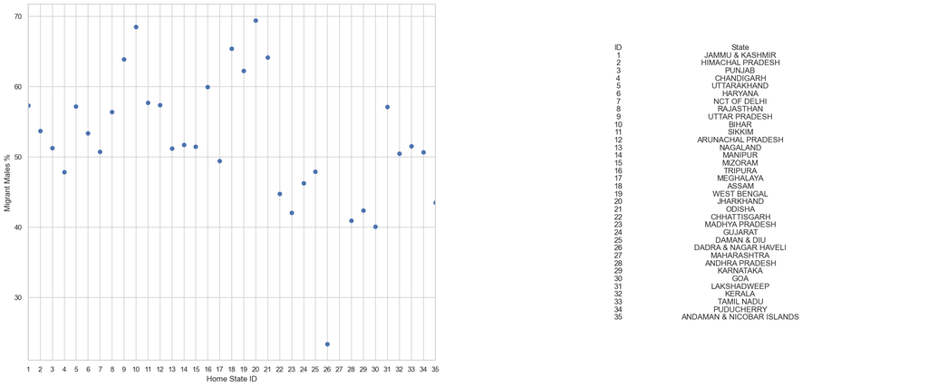

```python
dfMaharashtra = df[df['Current State ID'] == 27]
dfMaharashtra = dfMaharashtra.rename({'Migrant Males' : 'Migrant Males %'}, axis=1)
dfMaharashtra['Migrant Males %'] = dfMaharashtra['Migrant Males %']/dfMaharashtra['Migrant Persons']*100
# print(dfMaharashtra)

# plot Migrant Males % against Home State ID
fig, (ax3, ax4) = plt.subplots(1,2)
fig.set_size_inches(25, 10)
ax3.plot(dfMaharashtra['Home State ID'], dfMaharashtra['Migrant Males %'], 'o')
ax3.xaxis.grid(True, "minor", linewidth=.25)
ax3.yaxis.grid(True, "minor", linewidth=.25)
ax3.set_xlim(1, 35)
start, end = ax1.get_xlim()
ax3.xaxis.set_ticks(np.arange(1, 36, 1))
ax3.xaxis.set_major_formatter(ticker.FormatStrFormatter('%d'))
ax3.set_xlabel('Home State ID')
ax3.set_ylabel('Migrant Males %')


ax4.axis('off')
ax4.table(cellText=IDs.values, colLabels=IDs.columns, loc='center', colWidths=[0.1, 0.5],cellLoc='center',edges='open')
```

To further understand this data about percentage of males migrating to Maharashtra, we once again plot it on the map of India

[output not shown]

[output cut: 174 more lines]

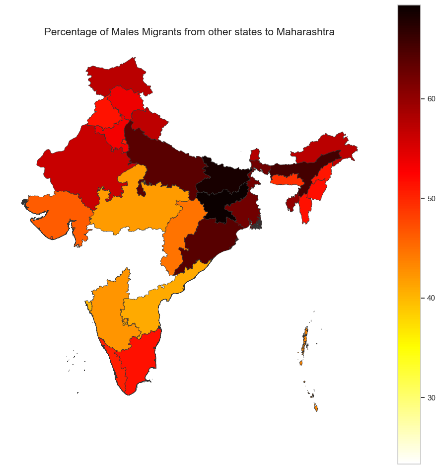

```python
map_dfNeighbour = gpd.read_file('IND_adm/IND_adm1.shp')
# Rename some states
map_dfNeighbour = map_dfNeighbour.replace({'Andaman and Nicobar':'ANDAMAN & NICOBAR ISLANDS', 'Andhra Pradesh':'ANDHRA PRADESH', 'Arunachal Pradesh':'ARUNACHAL PRADESH', 'Chhattisgarh':'CHHATTISGARH', 'Dadra and Nagar Haveli':'DADRA & NAGAR HAVELI', 'Daman and Diu':'DAMAN & DIU', 'Delhi':'NCT OF DELHI', 'Jammu and Kashmir':'JAMMU & KASHMIR', 'Lakshadweep':'LAKSHADWEEP', 'Madhya Pradesh':'MADHYA PRADESH', 'Maharashtra':'MAHARASHTRA', 'Bihar':'BIHAR', 'Assam':'ASSAM', 'Chandigarh':'CHANDIGARH','Goa':'GOA','Gujarat':'GUJARAT','Haryana':'HARYANA','Himachal Pradesh':'HIMACHAL PRADESH','Jharkhand':'JHARKHAND','Karnataka':'KARNATAKA','Kerala':'KERALA','Mizoram':'MIZORAM','Nagaland':'NAGALAND','Orissa':'ODISHA','Puducherry':'PUDUCHERRY','Punjab':'PUNJAB','Rajasthan':'RAJASTHAN','Sikkim':'SIKKIM','Tamil Nadu':'TAMIL NADU','Telangana':'TELANGANA','Tripura':'TRIPURA','Uttar Pradesh':'UTTAR PRADESH','Uttarakhand':'UTTARAKHAND','West Bengal':'WEST BENGAL','Uttaranchal':'UTTARAKHAND','Manipur':'MANIPUR','Meghalaya':'MEGHALAYA'})
# print(map_df)
dfMergeem = pd.merge(map_dfNeighbour, dfMaharashtra, left_on='NAME_1', right_on='Home State Name', how='left')
print(dfMerge)
fig, ax = plt.subplots(1, figsize=(12, 12))
ax.axis('off')
ax.set_title('Percentage of Males Migrants from other states to Maharashtra',
             fontdict={'fontsize': '15', 'fontweight' : '3'})
fig = dfMergeem.plot(column='Migrant Males %', cmap='hot_r', linewidth=0.5, ax=ax, edgecolor='0.2',legend=True)
```

We notice that Bihar and Jharkhand present one of the highest % of migrant males to Maharashtra. Clearly, the trend implies a mass gended biased migration of people from these states to Maharashtra.

## End of Question 3